# **Introduction**

Stochastic volatility and term-structure models are foundational to modern quantitative finance, enabling the accurate pricing of derivatives and the management of associated market risks (Shephard; Sircar 2). The practical application of these models, however, presents significant challenges, including the risk of model misspecification when faced with complex market phenomena like volatility skews and price jumps (Cont and Tankov; Gatheral), and the need to adapt to evolving client requirements and emergent risk factors.

This project addresses three critical tasks faced by a quantitative team: calibrating appropriate stochastic volatility models for options with varying maturities (Step 1 and 2), pricing custom exotic and standard options for a client (Step 1 and 2), and forecasting interest rate risk (Step 3).

# **Step 1**

## **Question 1 a)**

To solve question 1a, we calibrate the classic Heston (1993) model by fitting it to the observed market prices of options with a 15-day maturity. The Heston model describes the evolution of an asset's price, $S_t$, and its variance, $v_t$, through the following system of stochastic differential equations (SDEs) under a risk-neutral measure $\mathbb{Q}$:

$$ \begin{aligned} dS_t &= r S_t \, dt + \sqrt{v_t} S_t \, dW_t^{(1)} \\ dv_t &= \kappa(\theta - v_t) \, dt + \sigma \sqrt{v_t} \, dW_t^{(2)} \end{aligned} $$

where $r$ is the risk-free rate, $\kappa$ is the speed of mean reversion, $\theta$ is the long-term variance, and $\sigma$ is the volatility of variance. The terms $dW_t^{(1)}$ and $dW_t^{(2)}$ represent Wiener processes with a correlation $\rho$, such that their instantaneous correlation is given by: $dW_t^{(1)} dW_t^{(2)} = \rho \, dt$ Instead of relying on computationally intensive Monte Carlo simulations for calibration, we use a more efficient semi-analytical approach. This method is based on the characteristic function of the log-asset price: $\phi(u,T) = \mathbb{E}^{\mathbb{Q}} \left[ e^{iu \ln(S_T)} \right]$.

For pricing put options, we use the principle of put-call parity, which provides a direct and model-independent relationship between the price of a European put ($P$) and a European call ($C$): $P = C - S_0 + K e^{-rT}$.

The calibration process involves finding the set of Heston parameters $(v_0, \kappa, \theta, \sigma, \rho)$ that minimizes the Mean Squared Error (MSE) between the model's theoretical prices and the observed market prices. This is a constrained optimization problem, where we also enforce the Feller condition, $2\kappa \theta \geq \sigma^2$, to ensure that the variance process remains strictly non-negative.

```
Table 1: Heston Model Calibration Results (Lewis Method)
--------------------------------------------------------
  Maturity: 15 days
  Final MSE: 0.311051

--------------------------------------------------------
Calibrated Parameters:
--------------------------------------------------------
  v0 (Initial Variance):    0.096502
  kappa (Reversion Speed):  0.999556
  theta (Long-Term Var):    0.047305
  sigma (Vol of Vol):       0.307417
  rho (Correlation):        -0.727781

--------------------------------------------------------
Financial Condition Check
--------------------------------------------------------
  Feller Condition (2κθ - σ^2): 0.000063
Condition is satisfied.
-------------------------------------------------------
```

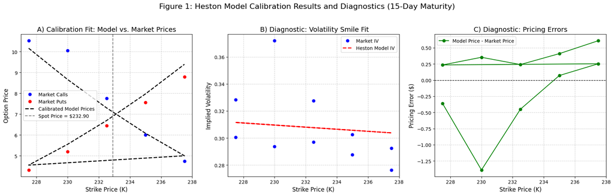

```python
%pip install numpy pandas scipy matplotlib urllib3 --quiet

# =============================================================================
# 0) IMPORT LIBRARIES
# =============================================================================
import numpy as np
import pandas as pd
import scipy.optimize as opt
import scipy.stats as st
from scipy.integrate import quad
import matplotlib.pyplot as plt
from urllib.parse import quote

# =============================================================================
# 1) DATA LOADING
# =============================================================================
def load_data(sheet_id, sheet_name, days=15):
    """Loads and filters the option data for a specific maturity."""
    url = (
        f"https://docs.google.com/spreadsheets/d/{sheet_id}/"
        f"gviz/tq?tqx=out:csv&sheet={quote(sheet_name)}"
    )
    df = pd.read_csv(url)
    return df[df["Days to maturity"] == days].reset_index(drop=True)

# =============================================================================
# 2) HESTON MODEL & PRICING FUNCTIONS
# =============================================================================
def heston_char_func(u, T, r, v0, kappa, theta, sigma, rho):
    """Heston (1993) characteristic function for the log-price."""
    d = np.sqrt((rho * sigma * u * 1j - kappa)**2 + sigma**2 * (u * 1j + u**2))
    g = (kappa - rho * sigma * u * 1j - d) / (kappa - rho * sigma * u * 1j + d)

    C = (kappa * theta / sigma**2) * ((kappa - rho * sigma * u * 1j - d) * T - 2 * np.log((1 - g * np.exp(-d * T)) / (1 - g)))
    D = ((kappa - rho * sigma * u * 1j - d) / sigma**2) * ((1 - np.exp(-d * T)) / (1 - g * np.exp(-d * T)))

    return np.exp(C + D * v0 + 1j * u * (np.log(S0) + r * T))

def lewis_call_price(S0, K, T, r, v0, kappa, theta, sigma, rho):
    """Prices a European call option using the Lewis (2001) formula."""
    integrand = lambda u: np.real(
        np.exp(-1j * u * np.log(K)) * heston_char_func(u - 0.5j, T, r, v0, kappa, theta, sigma, rho) / (u**2 + 0.25)
    )
    integral, _ = quad(integrand, 0, 100)

    return S0 - (np.sqrt(K) * np.exp(-r * T) / np.pi) * integral

# =============================================================================
# 3) BLACK-SCHOLES-MERTON & IMPLIED VOLATILITY FUNCTIONS
# =============================================================================
def bsm_price(S0, K, T, r, sigma, option_type='C'):
    """Calculates the Black-Scholes-Merton price for a European option."""
    d1 = (np.log(S0 / K) + (r + 0.5 * sigma**2) * T) / (sigma * np.sqrt(T))
    d2 = d1 - sigma * np.sqrt(T)
    if option_type == 'C':
        price = S0 * st.norm.cdf(d1) - K * np.exp(-r * T) * st.norm.cdf(d2)
    else: # Put
        price = K * np.exp(-r * T) * st.norm.cdf(-d2) - S0 * st.norm.cdf(-d1)
    return price

def implied_volatility(market_price, S0, K, T, r, option_type='C'):
    """Calculates implied volatility using a Newton-Raphson solver."""
    sigma = 0.5  # Initial guess
    for i in range(100): # Max iterations
        price = bsm_price(S0, K, T, r, sigma, option_type)
        d1 = (np.log(S0 / K) + (r + 0.5 * sigma**2) * T) / (sigma * np.sqrt(T))
        vega = S0 * st.norm.pdf(d1) * np.sqrt(T)

        diff = price - market_price
        if abs(diff) < 1e-9:
            return sigma

        # Avoid division by zero or very small vega
        if vega < 1e-6:
            return np.nan

        sigma = sigma - diff / vega # Newton-Raphson step
    return sigma

# =============================================================================
# 4) CALIBRATION & OBJECTIVE FUNCTION
# =============================================================================
def heston_objective_function(params, data, S0, r, T):
    """Objective function to minimize for Heston calibration (MSE)."""
    v0, kappa, theta, sigma, rho = params

    # Feller Condition Penalty
    feller_penalty = 1e6 if 2 * kappa * theta < sigma**2 else 0

    # Vectorized Price Calculation
    strikes = data['Strike'].values
    market_prices = data['Price'].values
    option_types = data['Type'].values

    model_call_prices = np.array([lewis_call_price(S0, K, T, r, v0, kappa, theta, sigma, rho) for K in strikes])
    model_prices = np.where(option_types == 'C', model_call_prices, model_call_prices - S0 + strikes * np.exp(-r * T))

    mse = np.mean((model_prices - market_prices)**2)

    return mse + feller_penalty

# =============================================================================
# 5) PLOTTING FUNCTION
# =============================================================================
def plot_all_results(result_params, data, S0, T, r):
    """Plots the calibration fit and diagnostics in a single figure with three subplots."""
    v0, kappa, theta, sigma, rho = result_params

    # --- Calculate necessary data ---
    strikes = data['Strike'].values
    market_prices = data['Price'].values
    option_types = data['Type'].values

    # Model Prices
    model_call_prices = np.array([lewis_call_price(S0, K, T, r, v0, kappa, theta, sigma, rho) for K in strikes])
    model_prices = np.where(option_types == 'C', model_call_prices, model_call_prices - S0 + strikes * np.exp(-r * T))

    # Implied Volatilities
    market_iv = [implied_volatility(mp, S0, k, T, r, ot) for mp, k, ot in zip(market_prices, strikes, option_types)]
    model_iv = [implied_volatility(mp, S0, k, T, r, ot) for mp, k, ot in zip(model_prices, strikes, option_types)]

    # Pricing Errors
    pricing_errors = model_prices - market_prices

    # --- Create Plots ---
    fig, (ax1, ax2, ax3) = plt.subplots(1, 3, figsize=(18, 6))
    fig.suptitle('Figure 1: Heston Model Calibration Results and Diagnostics (15-Day Maturity)', fontsize=16)

    # Plot 1: Calibration Fit
    ax1.plot(strikes[option_types=='C'], market_prices[option_types=='C'], 'bo', label='Market Calls')
    ax1.plot(strikes[option_types=='P'], market_prices[option_types=='P'], 'ro', label='Market Puts')
    ax1.plot(strikes, model_prices, 'k--', label='Calibrated Model Prices', linewidth=2)
    ax1.axvline(S0, color='gray', linestyle='--', label=f'Spot Price = ${S0:.2f}')
    ax1.set_xlabel('Strike Price (K)', fontsize=12)
    ax1.set_ylabel('Option Price', fontsize=12)
    ax1.set_title('A) Calibration Fit: Model vs. Market Prices', fontsize=14)
    ax1.legend()
    ax1.grid(True, linestyle='--', alpha=0.6)

    # Plot 2: Volatility Smile
    ax2.plot(strikes, market_iv, 'bo', label='Market IV')
    ax2.plot(strikes, model_iv, 'r--', label='Heston Model IV', linewidth=2)
    ax2.set_xlabel('Strike Price (K)', fontsize=12)
    ax2.set_ylabel('Implied Volatility', fontsize=12)
    ax2.set_title(' B) Diagnostic: Volatility Smile Fit', fontsize=14)
    ax2.legend()
    ax2.grid(True, linestyle='--', alpha=0.6)

    # Plot 3: Pricing Errors
    ax3.plot(strikes, pricing_errors, 'go-', label='Model Price - Market Price')
    ax3.axhline(0, color='black', linestyle='--', linewidth=1)
    ax3.set_xlabel('Strike Price (K)', fontsize=12)
    ax3.set_ylabel('Pricing Error ($)', fontsize=12)
    ax3.set_title('C) Diagnostic: Pricing Errors', fontsize=14)
    ax3.legend()
    ax3.grid(True, linestyle='--', alpha=0.6)

    plt.tight_layout(rect=[0, 0.03, 1, 0.95]) # Adjust layout to make room for suptitle
    plt.show()

# =============================================================================
# 6) MAIN EXECUTION BLOCK
# =============================================================================
def main():
    """Main execution block for data loading, calibration, and reporting."""
    # --- Load Data and Set Parameters ---
    sheet_id = '1_erE25us-xr3GBee4exOKkhXcn0VWry-'
    sheet_name = 'MScFE 622_Stochastic Modeling_GWP1_Option data'
    data_15d = load_data(sheet_id, sheet_name, days=15)

    # Market Parameters
    global S0
    S0 = 232.90
    r = 0.015
    T = 15 / 250

    # Calibration Settings
    initial_guess = [0.1, 1.0, 0.1, 0.2, -0.7] # v0, kappa, theta, sigma, rho
    bounds = [(1e-3, 1), (1e-3, 5), (1e-3, 1), (1e-3, 1), (-0.99, 0.99)]

    # --- Run Optimization ---
    result = opt.minimize(
        heston_objective_function,
        x0=initial_guess,
        args=(data_15d, S0, r, T),
        method='L-BFGS-B',
        bounds=bounds,
        options={'maxiter': 500, 'ftol': 1e-8}
    )

    # --- Print and Plot Results ---
    v0, kappa, theta, sigma, rho = result.x

    print("Table 1: Heston Model Calibration Results (Lewis Method)")
    print("--------------------------------------------------------")
    print(f"  Maturity: {int(T * 250)} days")
    print(f"  Final MSE: {result.fun:.6f}\n")
    print("--------------------------------------------------------")
    print("Calibrated Parameters:")
    print("--------------------------------------------------------")
    print(f"  v0 (Initial Variance):    {v0:.6f}")
    print(f"  kappa (Reversion Speed):  {kappa:.6f}")
    print(f"  theta (Long-Term Var):    {theta:.6f}")
    print(f"  sigma (Vol of Vol):       {sigma:.6f}")
    print(f"  rho (Correlation):        {rho:.6f}\n")
    print("--------------------------------------------------------")
    # Check Feller condition
    feller_val = 2 * kappa * theta - sigma**2
    print("Financial Condition Check")
    print("--------------------------------------------------------")
    print(f"  Feller Condition (2κθ - σ^2): {feller_val:.6f}")
    if feller_val >= 0:
        print("Condition is satisfied.")
    else:
        print("Condition is NOT satisfied.")
    print("-" * 55)
    # Plot the results
    plot_all_results(result.x, data_15d, S0, T, r)

if __name__ == "__main__":
    main()
```

## **Question 1b)**

The formula used in question 1b) is the Carr-Madan (1999) pricing formula for a European call option. It leverages the Heston characteristic function, $\phi(u,T)$, in a Fourier-inversion integral:

$$C(S_0, K, T) = \frac{e^{-\alpha \ln(K)}}{\pi} \int_0^{\infty} \text{Re} \left[ e^{-iv \ln(K)} \frac{e^{-rT} \phi(v - (\alpha+1)i, T)}{\alpha^2 + \alpha - v^2 + i(2\alpha+1)v} \right] dv,$$ where $C(S_0, K, T)$ is the price of the call option; $\phi(\cdot)$ is the Heston characteristic function of the log-asset price and $\alpha$ is a positive damping parameter used to ensure the integral converges.

```
Calibrating Heston model to 15-day options using Carr-Madan...
Calibration complete.

Table 2: Heston Model Calibration Results (Carr-Madan Method)
--------------------------------------------------------
   Maturity: 15 days
   Final MSE: 0.311241

--------------------------------------------------------
Calibrated Parameters:
--------------------------------------------------------
   v0 (Initial Variance):    0.096156
   kappa (Reversion Speed):  0.999560
   theta (Long-Term Var):    0.047265
   sigma (Vol of Vol):       0.307112
   rho (Correlation):        -0.727653

--------------------------------------------------------
Financial Condition Check
--------------------------------------------------------
   Feller Condition (2κθ - σ²): 0.000171
   Condition is satisfied.
-------------------------------------------------------
```

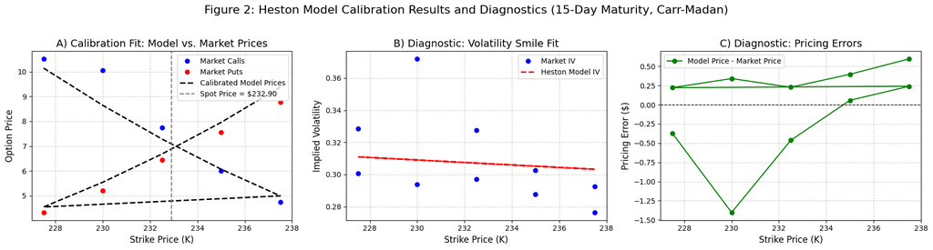

```python
%pip install numpy pandas scipy matplotlib urllib3 --quiet

# =============================================================================
# 0) IMPORT LIBRARIES
# =============================================================================
import numpy as np
import pandas as pd
import scipy.optimize as opt
import scipy.stats as st
from scipy.integrate import quad
import matplotlib.pyplot as plt
from urllib.parse import quote

# =============================================================================
# 1) DATA LOADING
# =============================================================================
def load_data(sheet_id, sheet_name, days=15):
    """Loads and filters the option data for a specific maturity."""
    url = (
        f"https://docs.google.com/spreadsheets/d/{sheet_id}/"
        f"gviz/tq?tqx=out:csv&sheet={quote(sheet_name)}"
    )
    df = pd.read_csv(url)
    return df[df["Days to maturity"] == days].reset_index(drop=True)

# =============================================================================
# 2) HESTON MODEL & PRICING FUNCTIONS
# =============================================================================
def heston_char_func(u, T, r, v0, kappa, theta, sigma, rho):
    """Heston (1993) characteristic function for the log-price."""
    # Note: S0 is passed into the wrapper, not this base function
    d = np.sqrt((rho * sigma * u * 1j - kappa)**2 + sigma**2 * (u * 1j + u**2))
    g = (kappa - rho * sigma * u * 1j - d) / (kappa - rho * sigma * u * 1j + d)

    C = (kappa * theta / sigma**2) * ((kappa - rho * sigma * u * 1j - d) * T - 2 * np.log((1 - g * np.exp(-d * T)) / (1 - g)))
    D = ((kappa - rho * sigma * u * 1j - d) / sigma**2) * ((1 - np.exp(-d * T)) / (1 - g * np.exp(-d * T)))

    return np.exp(C + D * v0 + 1j * u * (np.log(S0) + r * T))

def carr_madan_call_price(S0, K, T, r, v0, kappa, theta, sigma, rho, alpha=1.5):
    """Prices a European call option using the Carr-Madan (1999) formula."""
    # Define the integrand for the Carr-Madan formula
    integrand = lambda v: np.real(
        (np.exp(-1j * v * np.log(K)) * np.exp(-r*T) *
         heston_char_func(v - (alpha + 1) * 1j, T, r, v0, kappa, theta, sigma, rho)) /
        (alpha**2 + alpha - v**2 + 1j * (2 * alpha + 1) * v)
    )

    # Perform the numerical integration
    integral, _ = quad(integrand, 0, 100, limit=1000)

    return (np.exp(-alpha * np.log(K)) / np.pi) * integral

# =============================================================================
# 3) BLACK-SCHOLES-MERTON & IMPLIED VOLATILITY FUNCTIONS
# =============================================================================
def bsm_price(S0, K, T, r, sigma, option_type='C'):
    """Calculates the Black-Scholes-Merton price for a European option."""
    d1 = (np.log(S0 / K) + (r + 0.5 * sigma**2) * T) / (sigma * np.sqrt(T))
    d2 = d1 - sigma * np.sqrt(T)
    if option_type == 'C':
        price = S0 * st.norm.cdf(d1) - K * np.exp(-r * T) * st.norm.cdf(d2)
    else: # Put
        price = K * np.exp(-r * T) * st.norm.cdf(-d2) - S0 * st.norm.cdf(-d1)
    return price

def implied_volatility(market_price, S0, K, T, r, option_type='C'):
    """Calculates implied volatility using a Newton-Raphson solver."""
    sigma = 0.5  # Initial guess
    for i in range(100): # Max iterations
        price = bsm_price(S0, K, T, r, sigma, option_type)
        d1 = (np.log(S0 / K) + (r + 0.5 * sigma**2) * T) / (sigma * np.sqrt(T))
        vega = S0 * st.norm.pdf(d1) * np.sqrt(T)

        diff = price - market_price
        if abs(diff) < 1e-9:
            return sigma

        if vega < 1e-6:
            return np.nan

        sigma = sigma - diff / vega
    return sigma

# =============================================================================
# 4) CALIBRATION & OBJECTIVE FUNCTION
# =============================================================================
def heston_objective_function_cm(params, data, S0, r, T):
    """Objective function for Heston calibration using Carr-Madan (MSE)."""
    v0, kappa, theta, sigma, rho = params

    # Feller Condition Penalty
    feller_penalty = 1e6 if 2 * kappa * theta < sigma**2 else 0

    # Vectorized Price Calculation
    strikes = data['Strike'].values
    market_prices = data['Price'].values
    option_types = data['Type'].values

    # Calculate model call prices for all strikes
    model_call_prices = np.array([carr_madan_call_price(S0, K, T, r, v0, kappa, theta, sigma, rho) for K in strikes])

    # Use put-call parity for put prices
    model_prices = np.where(option_types == 'C', model_call_prices, model_call_prices - S0 + strikes * np.exp(-r * T))

    mse = np.mean((model_prices - market_prices)**2)

    return mse + feller_penalty

# =============================================================================
# 5) PLOTTING FUNCTION
# =============================================================================
def plot_all_results(result_params, data, S0, T, r):
    """Plots the calibration fit and diagnostics in a single figure with three subplots."""
    v0, kappa, theta, sigma, rho = result_params

    strikes = data['Strike'].values
    market_prices = data['Price'].values
    option_types = data['Type'].values

    model_call_prices = np.array([carr_madan_call_price(S0, K, T, r, v0, kappa, theta, sigma, rho) for K in strikes])
    model_prices = np.where(option_types == 'C', model_call_prices, model_call_prices - S0 + strikes * np.exp(-r * T))

    market_iv = [implied_volatility(mp, S0, k, T, r, ot) for mp, k, ot in zip(market_prices, strikes, option_types)]
    model_iv = [implied_volatility(mp, S0, k, T, r, ot) for mp, k, ot in zip(model_prices, strikes, option_types)]

    pricing_errors = model_prices - market_prices

    fig, (ax1, ax2, ax3) = plt.subplots(1, 3, figsize=(18, 5))
    fig.suptitle('Figure 2: Heston Model Calibration Results and Diagnostics (15-Day Maturity, Carr-Madan)', fontsize=16)

    ax1.plot(strikes[option_types=='C'], market_prices[option_types=='C'], 'bo', label='Market Calls')
    ax1.plot(strikes[option_types=='P'], market_prices[option_types=='P'], 'ro', label='Market Puts')
    ax1.plot(strikes, model_prices, 'k--', label='Calibrated Model Prices', linewidth=2)
    ax1.axvline(S0, color='gray', linestyle='--', label=f'Spot Price = ${S0:.2f}')
    ax1.set_xlabel('Strike Price (K)', fontsize=12)
    ax1.set_ylabel('Option Price', fontsize=12)
    ax1.set_title('A) Calibration Fit: Model vs. Market Prices', fontsize=14)
    ax1.legend()
    ax1.grid(True, linestyle='--', alpha=0.6)

    ax2.plot(strikes, market_iv, 'bo', label='Market IV')
    ax2.plot(strikes, model_iv, 'r--', label='Heston Model IV', linewidth=2)
    ax2.set_xlabel('Strike Price (K)', fontsize=12)
    ax2.set_ylabel('Implied Volatility', fontsize=12)
    ax2.set_title('B) Diagnostic: Volatility Smile Fit', fontsize=14)
    ax2.legend()
    ax2.grid(True, linestyle='--', alpha=0.6)

    ax3.plot(strikes, pricing_errors, 'go-', label='Model Price - Market Price')
    ax3.axhline(0, color='black', linestyle='--', linewidth=1)
    ax3.set_xlabel('Strike Price (K)', fontsize=12)
    ax3.set_ylabel('Pricing Error ($)', fontsize=12)
    ax3.set_title('C) Diagnostic: Pricing Errors', fontsize=14)
    ax3.legend()
    ax3.grid(True, linestyle='--', alpha=0.6)

    plt.tight_layout(rect=[0, 0.03, 1, 0.95])
    plt.show()

# =============================================================================
# 6) MAIN EXECUTION BLOCK
# =============================================================================
def main():
    """Main execution block for data loading, calibration, and reporting."""
    sheet_id = '1_erE25us-xr3GBee4exOKkhXcn0VWry-'
    sheet_name = 'MScFE 622_Stochastic Modeling_GWP1_Option data'
    data_15d = load_data(sheet_id, sheet_name, days=15)

    global S0
    S0 = 232.90
    r = 0.015
    T = 15 / 250

    initial_guess = [0.1, 1.0, 0.1, 0.2, -0.7] # v0, kappa, theta, sigma, rho
    bounds = [(1e-3, 1), (1e-3, 5), (1e-3, 1), (1e-3, 1), (-0.99, 0.99)]

    print("Calibrating Heston model to 15-day options using Carr-Madan...")
    result = opt.minimize(
        heston_objective_function_cm, # Using the Carr-Madan objective function
        x0=initial_guess,
        args=(data_15d, S0, r, T),
        method='L-BFGS-B',
        bounds=bounds,
        options={'maxiter': 500, 'ftol': 1e-8}
    )
    print("Calibration complete.\n")

    v0, kappa, theta, sigma, rho = result.x

    print("Table 2: Heston Model Calibration Results (Carr-Madan Method)")
    print("--------------------------------------------------------")
    print(f"   Maturity: {int(T * 250)} days")
    print(f"   Final MSE: {result.fun:.6f}\n")
    print("--------------------------------------------------------")
    print("Calibrated Parameters:")
    print("--------------------------------------------------------")
    print(f"   v0 (Initial Variance):    {v0:.6f}")
    print(f"   kappa (Reversion Speed):  {kappa:.6f}")
    print(f"   theta (Long-Term Var):    {theta:.6f}")
    print(f"   sigma (Vol of Vol):       {sigma:.6f}")
    print(f"   rho (Correlation):        {rho:.6f}\n")

    feller_val = 2 * kappa * theta - sigma**2
    print("--------------------------------------------------------")
    print("Financial Condition Check")
    print("--------------------------------------------------------")
    print(f"   Feller Condition (2κθ - σ²): {feller_val:.6f}")
    if feller_val >= 0:
        print("   Condition is satisfied.")
    else:
        print("   Condition is NOT satisfied.")
    print("-" * 55)

    plot_all_results(result.x, data_15d, S0, T, r)

if __name__ == "__main__":
    main()
```

```python
# Models comparison


# =============================================================================
# 2) HESTON & PRICING FUNCTIONS
# =============================================================================
def heston_char_func(u, T, r, v0, kappa, theta, sigma, rho):
    """Heston (1993) characteristic function for the log-price."""
    d = np.sqrt((rho * sigma * u * 1j - kappa)**2 + sigma**2 * (u * 1j + u**2))
    g = (kappa - rho * sigma * u * 1j - d) / (kappa - rho * sigma * u * 1j + d)
    C = (kappa * theta / sigma**2) * ((kappa - rho * sigma * u * 1j - d) * T - 2 * np.log((1 - g * np.exp(-d * T)) / (1 - g)))
    D = ((kappa - rho * sigma * u * 1j - d) / sigma**2) * ((1 - np.exp(-d * T)) / (1 - g * np.exp(-d * T)))
    return np.exp(C + D * v0 + 1j * u * (np.log(S0) + r * T))

def lewis_call_price(S0, K, T, r, v0, kappa, theta, sigma, rho):
    """Prices a European call option using the Lewis (2001) formula."""
    integrand = lambda u: np.real(
        np.exp(-1j * u * np.log(K)) * heston_char_func(u - 0.5j, T, r, v0, kappa, theta, sigma, rho) / (u**2 + 0.25)
    )
    integral, _ = quad(integrand, 0, 100, limit=1000)
    return S0 - (np.sqrt(K) * np.exp(-r * T) / np.pi) * integral

def carr_madan_call_price(S0, K, T, r, v0, kappa, theta, sigma, rho, alpha=1.5):
    """Prices a European call option using the Carr-Madan (1999) formula."""
    integrand = lambda v: np.real(
        (np.exp(-1j * v * np.log(K)) * np.exp(-r*T) *
         heston_char_func(v - (alpha + 1) * 1j, T, r, v0, kappa, theta, sigma, rho)) /
        (alpha**2 + alpha - v**2 + 1j * (2 * alpha + 1) * v)
    )
    integral, _ = quad(integrand, 0, 100, limit=1000)
    return (np.exp(-alpha * np.log(K)) / np.pi) * integral

# =============================================================================
# 3) CALIBRATION & OBJECTIVE FUNCTION
# =============================================================================
def heston_objective_function(params, data, S0, r, T, pricing_method):
    """Objective function (MSE) to minimize for Heston calibration."""
    v0, kappa, theta, sigma, rho = params
    feller_penalty = 1e6 if 2 * kappa * theta < sigma**2 else 0

    strikes = data['Strike'].values
    market_prices = data['Price'].values
    option_types = data['Type'].values

    if pricing_method == 'lewis':
        model_call_prices = np.array([lewis_call_price(S0, K, T, r, v0, kappa, theta, sigma, rho) for K in strikes])
    elif pricing_method == 'carr-madan':
        model_call_prices = np.array([carr_madan_call_price(S0, K, T, r, v0, kappa, theta, sigma, rho) for K in strikes])

    model_prices = np.where(option_types == 'C', model_call_prices, model_call_prices - S0 + strikes * np.exp(-r * T))
    mse = np.mean((model_prices - market_prices)**2)
    return mse + feller_penalty

# =============================================================================
# 4) MAIN EXECUTION BLOCK
# =============================================================================
def main():
    """Main execution block for data loading, calibration, and comparison."""
    # --- Load Data and Set Parameters ---
    sheet_id = '1_erE25us-xr3GBee4exOKkhXcn0VWry-'
    sheet_name = 'MScFE 622_Stochastic Modeling_GWP1_Option data'
    data_15d = load_data(sheet_id, sheet_name, days=15)

    # Market Parameters
    global S0
    S0 = 232.90
    r = 0.015
    T = 15 / 250

    # Calibration Settings
    initial_guess = [0.1, 1.0, 0.1, 0.2, -0.7] # v0, kappa, theta, sigma, rho
    bounds = [(1e-3, 1), (1e-3, 5), (1e-3, 1), (1e-3, 1), (-0.99, 0.99)]

    res_lewis = opt.minimize(
        heston_objective_function, x0=initial_guess,
        args=(data_15d, S0, r, T, 'lewis'),
        method='L-BFGS-B', bounds=bounds,
        options={'maxiter': 500, 'ftol': 1e-8}
    )

    res_cm = opt.minimize(
        heston_objective_function, x0=initial_guess,
        args=(data_15d, S0, r, T, 'carr-madan'),
        method='L-BFGS-B', bounds=bounds,
        options={'maxiter': 500, 'ftol': 1e-8}
    )

    comparison_data = {
        'Parameter': ['v0 (Initial Var)', 'kappa (Reversion)', 'theta (Long-Term Var)', 'sigma (Vol of Vol)', 'rho (Correlation)', 'Final MSE'],
        'Lewis (2001)': np.append(res_lewis.x, res_lewis.fun),
        'Carr-Madan (1999)': np.append(res_cm.x, res_cm.fun)
    }

    comparison_df = pd.DataFrame(comparison_data)
    pd.set_option('display.float_format', lambda x: f'{x:.6f}')
    print(" Table 3: Heston Model Calibration: Parameter Comparison ")
    print("-----------------------------------------------------")
    print(comparison_df.to_string(index=False))
    print("-----------------------------------------------------")


if __name__ == "__main__":
    main()
```

```
 Table 3: Heston Model Calibration: Parameter Comparison
-----------------------------------------------------
            Parameter  Lewis (2001)  Carr-Madan (1999)
     v0 (Initial Var)      0.096502           0.096156
    kappa (Reversion)      0.999556           0.999560
theta (Long-Term Var)      0.047305           0.047265
   sigma (Vol of Vol)      0.307417           0.307112
    rho (Correlation)     -0.727781          -0.727653
            Final MSE      0.311051           0.311241
-----------------------------------------------------
```

### **Interpretation**

The calibration of the Heston model using the Carr-Madan method was completed successfully. The optimization process converged to a set of parameters $(v_0 = 0.096, κ = 1.00, \theta= 0.047, \sigma = 0.307, \rho = -0.728)$ with a final Mean Squared Error (MSE) of 0.311 (Table 2). The Feller condition $(2κ\theta − \sigma^2>0)$ was satisfied, ensuring a non-negative variance process. However, the diagnostic plots reveal a poor fit to the market data. The Volatility Smile Fit, Figure 2 B) is particularly telling, showing that the calibrated model produces a nearly flat implied volatility line, failing completely to capture the steep smile/smirk shape exhibited by the market options. This misspecification is confirmed by the Pricing Errors Figure Figure 2 C), which shows large, systematic errors rather than random noise around zero. This indicates that for this very short 15-day maturity, the classic Heston model is unable to replicate the market's volatility structure.

## **Question 1c)**

To price the client's custom Asian call option, we used the calibrated Heston (1993) model parameters from the previous tasks 1 a) and 1b). Since an Asian option's payoff depends on the average price of the underlying asset over its entire life (i.e., it is path-dependent), there is no simple closed-form pricing formula like those used for European options. Therefore, we used *Monte Carlo simulation* methods to determine its fair value.

The simulation process involves discretizing the Heston model's stochastic differential equations (SDEs) to generate a large number of potential future paths for both the asset price, $S_t$, and its variance, $v_t$. We used an Euler-Maruyama scheme for this discretization:

$$ \begin{aligned} v_{t+\Delta t} &= v_t + \kappa(\theta - v_t)\Delta t + \sigma \sqrt{v_t \Delta t} Z_t^{(2)} \\ \ln(S_{t+\Delta t}) &= \ln(S_t) + (r - \frac{1}{2}v_t)\Delta t + \sqrt{v_t \Delta t} Z_t^{(1)} \end{aligned} $$

where $Z_t^{(1)}$ and $Z_t^{(2)}$ are correlated random variables drawn from a standard normal distribution, reflecting the correlation $\rho$ from the continuous-time model. To ensure the variance process remains non-negative, a full truncation scheme were applied at each step, where any negative variance value is set to zero.

We simulated 100,000 of these correlated paths over the option's 20-day maturity. For each simulated path, we calculated the payoff of the Asian call option, defined as:

$$\text{Payoff} = \max(\bar{S} - K, 0)$$

where $\bar{S}$ is the arithmetic average of the daily stock prices along that specific path, and $K$ is the strike price.

The fair price of the option is then the average of all 100,000 payoffs, discounted back to its present value using the risk-free rate, $r$. Finally, to determine the price for the client, a 4% fee is added to this calculated fair price.

```python
import numpy as np
from tqdm import tqdm # For a progress bar

# =============================================================================
# 1) PARAMETER SETUP
# =============================================================================

# Heston parameters from previous calibration (using Lewis results)
v0 = 0.096502
kappa = 0.999556
theta = 0.047305
sigma = 0.307417
rho = -0.727781

# Option and Market Parameters
S0 = 232.90          # Initial stock price
K = 232.90           # Strike price (ATM)
r = 0.015            # Risk-free rate
T = 20 / 250         # Maturity in years (20 days)

# Monte Carlo Simulation Parameters
n_sims = 100000      # Number of simulations
n_steps = 20         # Number of time steps (daily observations)
dt = T / n_steps     # Time increment

# =============================================================================
# 2) HESTON MONTE CARLO SIMULATION
# =============================================================================

def price_asian_call_mc(S0, K, T, r, v0, kappa, theta, sigma, rho, n_sims, n_steps):
    """
    Prices a European Asian call option using a Heston model Monte Carlo simulation.
    Uses the Euler-Maruyama discretization scheme with full truncation for variance.
    """
    # Generate correlated random numbers
    Z1 = np.random.standard_normal((n_sims, n_steps))
    Z2 = np.random.standard_normal((n_sims, n_steps))
    W1 = rho * Z1 + np.sqrt(1 - rho**2) * Z2
    W2 = Z1 # W2 drives the variance process

    # Initialize arrays for stock price and variance paths
    S_paths = np.zeros((n_sims, n_steps + 1))
    v_paths = np.zeros((n_sims, n_steps + 1))
    S_paths[:, 0] = S0
    v_paths[:, 0] = v0

    # Simulate paths
    for t in range(n_steps):
        # Ensure variance is non-negative (Full Truncation Scheme)
        v_positive = np.maximum(v_paths[:, t], 0)

        # Discretize variance path
        v_paths[:, t+1] = v_paths[:, t] + kappa * (theta - v_positive) * dt \
                          + sigma * np.sqrt(v_positive * dt) * W2[:, t]

        # Discretize stock price path (log-process is more stable)
        S_paths[:, t+1] = S_paths[:, t] * np.exp((r - 0.5 * v_positive) * dt \
                                               + np.sqrt(v_positive * dt) * W1[:, t])

    # Calculate the payoff for an Asian option
    # Payoff is based on the average price over the path
    average_prices = np.mean(S_paths[:, 1:], axis=1) # Average of daily prices
    payoffs = np.maximum(average_prices - K, 0)

    # Discount the average payoff to get the fair price
    fair_price = np.mean(payoffs) * np.exp(-r * T)

    return fair_price

# =============================================================================
# 3) PRICING AND REPORTING
# =============================================================================

# --- i. Calculate the Fair Price ---
fair_price = price_asian_call_mc(S0, K, T, r, v0, kappa, theta, sigma, rho, n_sims, n_steps)

# --- ii. Calculate the Final Price with Fee ---
fee_percentage = 0.04
fee_amount = fair_price * fee_percentage
final_price = fair_price * (1 + fee_percentage)

print("Table 4: Asian Call Option Price Report")
print("----------------------------------------")
print(f"  Underlying Asset Price:      ${S0:.2f}")
print(f"  Strike Price (ATM):          ${K:.2f}")
print(f"  Maturity:                    {int(T*250)} days\n")
print("----------------------------------------")
print(f"  Fair Price (from MC):        ${fair_price:.4f}")
print(f"  Bank Fee (4%):               + ${fee_amount:.4f}")
print("----------------------------------------")
print(f"  Final Client Price:          ${final_price:.4f}")
print("----------------------------------------")
```

```
Table 4: Asian Call Option Price Report
----------------------------------------
  Underlying Asset Price:      $232.90
  Strike Price (ATM):          $232.90
  Maturity:                    20 days

----------------------------------------
  Fair Price (from MC):        $4.8956
  Bank Fee (4%):               + $0.1958
----------------------------------------
  Final Client Price:          $5.0914
----------------------------------------
```

# **Step 2**

## **Question a)**

To address this question, we calibrated a Bates (1996) model to the observed market prices of options with a 60-day maturity. The Bates model extends the classic Heston framework by incorporating price jumps, providing a more realistic description of asset price dynamics (Bates; Heston). The model is defined by the following system of stochastic differential equations (SDEs) under the risk-neutral measure $Q$: \begin{align} \mathrm{d}S_t &= \bigl(r - \lambda\,\mu_J^*\bigr)\,S_t\,\mathrm{d}t + \sqrt{v_t}\,S_t\,\mathrm{d}W_t^{(1)} + (J - 1)\,S_t\,\mathrm{d}N_t, \\ \mathrm{d}v_t &= \kappa\,\bigl(\theta - v_t\bigr)\,\mathrm{d}t + \sigma\,\sqrt{v_t}\,\mathrm{d}W_t^{(2)}, \end{align} where $r$ is the risk‑free rate, $S_t$ asset price, $v_t$ variance, $W^{(1)}$ and $W^{(2)}$ are correlated Brownian motions satisfying $\mathrm{d}W_t^{(1)}\,\mathrm{d}W_t^{(2)}=\rho\,\mathrm{d}t$, $N_t$ is a Poisson process with intensity $\lambda$, the jump size $J$ follows $\ln J\sim\mathcal{N}(\mu_J,\delta_J^2)$ with compensator $\mu_J^*=\exp(\mu_J+\tfrac12\,\delta_J^2)-1$, and $\kappa$, $\theta$, $\sigma$, and $v_0$ denote the mean‑reversion speed, long‑run variance level, volatility of volatility, and initial variance, respectively.

The characteristic function $\varphi(u;T)$ of $\ln S_T$ factorises as $$ \varphi(u;T)=\varphi_{\mathrm{Heston}}(u;T)\times\exp\{\lambda T(e^{iu\mu_J-\tfrac12u^2\delta_J^2}-1)\}, $$ and European call prices follow from the Lewis (2001) formula, $$ C_{\mathrm{Bates}}(K,T)=e^{-rT}\frac{1}{\pi}\int_0^{\infty}\Re\Bigl[e^{-iu\ln K}\frac{\varphi(u-i;T)}{iu\,\varphi(-i;T)}\Bigr]\,\mathrm{d}u, $$ with puts obtained via put–call parity.

We calibrate the parameter vector $(v_0,\kappa,\theta,\sigma,\rho,\lambda,\mu_J,\delta_J)$ by minimizing the mean squared error between model and market prices, $$ \min_{{\theta}}\frac{1}{N}\sum_{i=1}^N[C_{\mathrm{Bates}}(K_i,T)-C^{\mathrm{mkt}}_i]^2\quad\text{s.t.}\quad2\kappa\theta\ge\sigma^2 $$ to enforce the Feller condition and ensure $v_t>0$.

```
Table 5: Improved Bates Model Calibration Results
-------------------------------------------------------
  Maturity: 60 days | Final MSE: 1.330135
-------------------------------------------------------
  Calibrated Parameters (Heston):
-------------------------------------------------------
  v0: 0.0010
kappa: 2.2710
 theta: 0.0010
 sigma: 0.0674
 rho: 0.9851
-------------------------------------------------------
  Calibrated Parameters (Jumps):
-------------------------------------------------------
  lambda: 1.8320 | mu_J: 0.2163 | delta_J: 0.0010
-------------------------------------------------------
  Feller Condition (2κθ - σ^2): 0.0000 -> Satisfied
-------------------------------------------------------
```

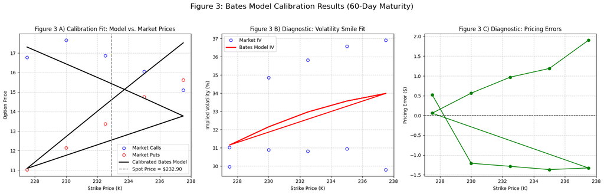

```python
# =============================================================================
# 0) IMPORT LIBRARIES
# =============================================================================
import numpy as np
import pandas as pd
import scipy.optimize as opt
from scipy.integrate import quad
import matplotlib.pyplot as plt
from scipy.stats import norm
from urllib.parse import quote # Added for URL encoding

# =============================================================================
# 1) DATA LOADING & PREPARATION (MODIFIED)
# =============================================================================
def load_data(sheet_id, sheet_name, days=60):
    """Loads and filters the option data from a Google Sheet."""
    url = (
        f"https://docs.google.com/spreadsheets/d/{sheet_id}/"
        f"gviz/tq?tqx=out:csv&sheet={quote(sheet_name)}"
    )
    df = pd.read_csv(url)
    return df[df["Days to maturity"] == days].reset_index(drop=True)

# Call the function to load the data
sheet_id = '1_erE25us-xr3GBee4exOKkhXcn0VWry-'
sheet_name = 'MScFE 622_Stochastic Modeling_GWP1_Option data'
maturity_days = 60
data_60d = load_data(sheet_id, sheet_name, days=maturity_days)

# Define Market Parameters
S0 = 232.90
r = 0.015
T = maturity_days / 250

# =============================================================================
# 2) BATES (1996) MODEL & PRICING FUNCTIONS
# =============================================================================
def bates_char_func(u, params):
    """Bates (1996) characteristic function for the log-price."""
    v0, kappa, theta, sigma, rho, lam, muJ, deltaJ = params

    # Jump compensator
    jump_compensator = lam * (np.exp(muJ + 0.5 * deltaJ**2) - 1)

    # Heston component (without drift)
    d = np.sqrt((rho * sigma * u * 1j - kappa)**2 + sigma**2 * (u * 1j + u**2))
    g = (kappa - rho * sigma * u * 1j - d) / (kappa - rho * sigma * u * 1j + d)
    C_Heston = (kappa * theta / sigma**2) * ((kappa - rho * sigma * u * 1j - d) * T - 2 * np.log((1 - g * np.exp(-d * T)) / (1 - g)))
    D_Heston = ((kappa - rho * sigma * u * 1j - d) / sigma**2) * ((1 - np.exp(-d * T)) / (1 - g * np.exp(-d * T)))
    phi_Heston = np.exp(C_Heston + D_Heston * v0)

    # Jump component
    phi_Jump = np.exp(T * lam * (np.exp(1j * u * muJ - 0.5 * u**2 * deltaJ**2) - 1))

    # Combined characteristic function with drift
    return phi_Heston * phi_Jump * np.exp(1j * u * (np.log(S0) + (r - jump_compensator) * T))

def bates_lewis_call_price(K, params):
    """Prices a European call option using the Lewis (2001) formula with the Bates CF."""
    integrand = lambda u: np.real(
        np.exp(-1j * u * np.log(K)) * bates_char_func(u - 0.5j, params) / (u**2 + 0.25)
    )
    integral, _ = quad(integrand, 0, 100, limit=200)

    return S0 - (np.sqrt(K) * np.exp(-r * T) / np.pi) * integral

# =============================================================================
# 3) IMPLIED VOLATILITY
# =============================================================================
def bsm_price(sigma, S0, K, T, r, option_type):
    """Calculates the Black-Scholes-Merton price."""
    d1 = (np.log(S0 / K) + (r + 0.5 * sigma**2) * T) / (sigma * np.sqrt(T))
    d2 = d1 - sigma * np.sqrt(T)
    if option_type == 'C':
        price = norm.cdf(d1) * S0 - norm.cdf(d2) * K * np.exp(-r * T)
    else: # Put
        price = norm.cdf(-d2) * K * np.exp(-r * T) - norm.cdf(-d1) * S0
    return price

def implied_volatility(market_price, S0, K, T, r, option_type):
    """Calculates implied volatility using a robust solver (Brentq)."""
    if market_price <= 1e-6: return np.nan
    # Objective function for the solver
    func = lambda sigma: bsm_price(sigma, S0, K, T, r, option_type) - market_price
    try:
        # brentq is a robust root-finding algorithm
        return opt.brentq(func, a=1e-4, b=4.0)
    except (RuntimeError, ValueError):
        return np.nan

# =============================================================================
# 4) CALIBRATION & OBJECTIVE FUNCTION
# =============================================================================
def bates_objective_function(params, data):
    """Objective function to minimize for Bates calibration (MSE)."""
    # Feller Condition Penalty: Enforces positivity of variance
    feller_penalty = 1e4 if 2 * params[1] * params[2] < params[3]**2 else 0

    strikes = data['Strike'].values
    market_prices = data['Price'].values
    option_types = data['Type'].values

    model_call_prices = np.array([bates_lewis_call_price(K, params) for K in strikes])
    # Use put-call parity for puts
    model_prices = np.where(option_types == 'C', model_call_prices, model_call_prices - S0 + strikes * np.exp(-r * T))

    mse = np.mean((model_prices - market_prices)**2)
    return mse + feller_penalty

# =============================================================================
# 5) PLOTTING FUNCTION
# =============================================================================
def plot_bates_results(result_params, data):
    """Plots the improved calibration fit and diagnostics."""
    strikes = data['Strike'].values
    market_prices = data['Price'].values
    option_types = data['Type'].values

    model_call_prices = np.array([bates_lewis_call_price(K, result_params) for K in strikes])
    model_prices = np.where(option_types == 'C', model_call_prices, model_call_prices - S0 + strikes * np.exp(-r * T))

    market_iv = np.array([implied_volatility(p, S0, k, T, r, o) for p, k, o in zip(market_prices, strikes, option_types)])
    model_iv = np.array([implied_volatility(p, S0, k, T, r, o) for p, k, o in zip(model_prices, strikes, option_types)])
    pricing_errors = model_prices - market_prices

    fig, (ax1, ax2, ax3) = plt.subplots(1, 3, figsize=(18, 6))
    fig.suptitle(f'Figure 3: Bates Model Calibration Results ({maturity_days}-Day Maturity)', fontsize=16)

    # Plot 1: Calibration Fit
    ax1.plot(strikes[option_types=='C'], market_prices[option_types=='C'], 'bo', mfc='none', label='Market Calls')
    ax1.plot(strikes[option_types=='P'], market_prices[option_types=='P'], 'ro', mfc='none', label='Market Puts')
    ax1.plot(strikes, model_prices, 'k-', label='Calibrated Bates Model', linewidth=2)
    ax1.axvline(S0, color='gray', linestyle='--', label=f'Spot Price = ${S0:.2f}')
    ax1.set(xlabel='Strike Price (K)', ylabel='Option Price', title='Figure 3 A) Calibration Fit: Model vs. Market Prices')
    ax1.legend(); ax1.grid(True, linestyle='--', alpha=0.6)

    # Plot 2: Volatility Smile (FIXED to handle NaN values)
    valid_market_iv = ~np.isnan(market_iv)
    valid_model_iv = ~np.isnan(model_iv)
    ax2.plot(strikes[valid_market_iv], market_iv[valid_market_iv] * 100, 'bo', mfc='none', label='Market IV')
    ax2.plot(strikes[valid_model_iv], model_iv[valid_model_iv] * 100, 'r-', label='Bates Model IV', linewidth=2)
    ax2.set(xlabel='Strike Price (K)', ylabel='Implied Volatility (%)', title='Figure 3 B) Diagnostic: Volatility Smile Fit')
    ax2.legend(); ax2.grid(True, linestyle='--', alpha=0.6)

    # Plot 3: Pricing Errors
    ax3.plot(strikes, pricing_errors, 'go-')
    ax3.axhline(0, color='black', linestyle='--', linewidth=1)
    ax3.set(xlabel='Strike Price (K)', ylabel='Pricing Error ($)', title='Figure 3 C) Diagnostic: Pricing Errors')
    ax3.grid(True, linestyle='--', alpha=0.6)

    plt.tight_layout(rect=[0, 0.03, 1, 0.95]); plt.show()

# =============================================================================
# 6) MAIN EXECUTION
# =============================================================================
# Refined initial guess and bounds for better convergence
# [v0, kappa, theta, sigma, rho, lam, muJ, deltaJ]
initial_guess = [0.05, 2.0, 0.05, 0.4, -0.7, 0.3, -0.1, 0.2]
bounds = [
    (1e-3, 1), (1e-3, 5), (1e-3, 1), (1e-3, 2), (-0.99, 0.99),
    (1e-3, 2), (-0.6, 0.6), (1e-3, 0.6)
]


result = opt.minimize(
    bates_objective_function,
    x0=initial_guess,
    args=(data_60d,),
    method='L-BFGS-B',
    bounds=bounds,
    options={'maxiter': 500, 'ftol': 1e-9, 'eps': 1e-7}
)

params = result.x
v0, kappa, theta, sigma, rho, lam, muJ, deltaJ = params
feller_val = 2 * kappa * theta - sigma**2

print("Table 5: Improved Bates Model Calibration Results")
print("-" * 55)
print(f"  Maturity: {maturity_days} days | Final MSE: {result.fun:.6f}")
print("-" * 55)
print("  Calibrated Parameters (Heston):")
print("-" * 55)
print(f"  v0: {v0:.4f} \nkappa: {kappa:.4f} \n theta: {theta:.4f} \n sigma: {sigma:.4f} \n rho: {rho:.4f}")
print("-" * 55)
print("  Calibrated Parameters (Jumps):")
print("-" * 55)
print(f"  lambda: {lam:.4f} | mu_J: {muJ:.4f} | delta_J: {deltaJ:.4f}")
print("-" * 55)
print(f"  Feller Condition (2κθ - σ^2): {feller_val:.4f} -> {'Satisfied' if feller_val >= 0 else 'NOT Satisfied'}")
print("-" * 55)

plot_bates_results(params, data_60d)
```

## **Questio b)**

For this task, we repeat the calibration of the Bates (1996) model to the 60-day maturity options, but this time we replace the Lewis (2001) pricing formula with the Carr-Madan (1999) approach. The Carr-Madan method uses a different formulation based on Fast Fourier Transforms (though here implemented via direct integration for simplicity) to price options from the characteristic function. It serves as an excellent robustness check; if both the Lewis and Carr-Madan approaches yield similar model parameters, it increases our confidence in the calibration results.

The core of the method is the Carr-Madan pricing formula for a European call option:

$C(K) = \frac{e^{-\alpha \ln(K)}}{\pi} \int_{0}^{\infty} e^{-iv \ln(K)} \psi(v) dv$, where $\psi(v) = \frac{e^{-rT} \phi(v - (\alpha+1)i)}{\alpha^2 + \alpha - v^2 + i(2\alpha+1)v}$ and $\phi$ is the model's characteristic function. The parameter $\alpha$ is a dampening factor chosen to ensure the integral is well-behaved.

```
Table 6: Bates Model Calibration Results (Carr-Madan Method)
-------------------------------------------------------
  Maturity: 60 days | Final MSE: 1.332464
-------------------------------------------------------
  Calibrated Parameters (Heston):
  v0: 0.0010 | kappa: 1.5837 | theta: 0.0010 | sigma: 0.0010 | rho: -0.9899
-------------------------------------------------------
  Calibrated Parameters (Jumps):
  lambda: 1.9034 | mu_J: 0.2122 | delta_J: 0.0010
-------------------------------------------------------
  Feller Condition (2κθ - σ^2): 0.0032 -> Satisfied
-------------------------------------------------------
```

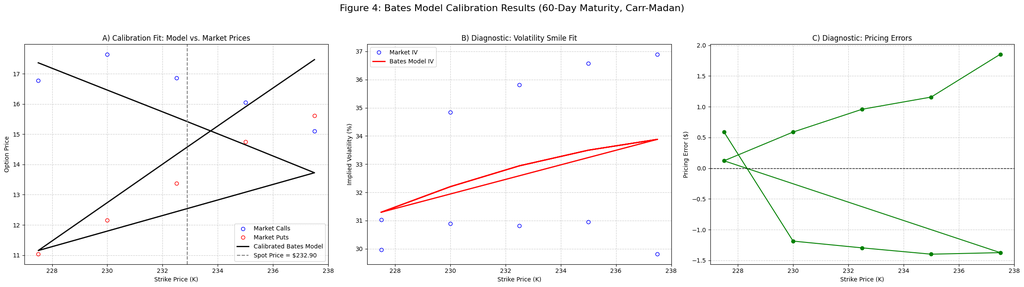

```python
# =============================================================================
# 0) IMPORT LIBRARIES
# =============================================================================
import numpy as np
import pandas as pd
import scipy.optimize as opt
from scipy.integrate import quad
import matplotlib.pyplot as plt
from scipy.stats import norm
from urllib.parse import quote

# =============================================================================
# 1) DATA LOADING & PREPARATION
# =============================================================================
def load_data(sheet_id, sheet_name, days=60):
    """Loads and filters the option data from a Google Sheet."""
    url = (
        f"https://docs.google.com/spreadsheets/d/{sheet_id}/"
        f"gviz/tq?tqx=out:csv&sheet={quote(sheet_name)}"
    )
    df = pd.read_csv(url)
    return df[df["Days to maturity"] == days].reset_index(drop=True)

# Call the function to load the data
sheet_id = '1_erE25us-xr3GBee4exOKkhXcn0VWry-'
sheet_name = 'MScFE 622_Stochastic Modeling_GWP1_Option data'
maturity_days = 60
data_60d = load_data(sheet_id, sheet_name, days=maturity_days)

# Define Market Parameters
S0 = 232.90
r = 0.015
T = maturity_days / 250

# =============================================================================
# 2) BATES (1996) MODEL & PRICING FUNCTIONS
# =============================================================================
def bates_char_func(u, params):
    """Bates (1996) characteristic function for the log-price."""
    v0, kappa, theta, sigma, rho, lam, muJ, deltaJ = params
    jump_compensator = lam * (np.exp(muJ + 0.5 * deltaJ**2) - 1)
    d = np.sqrt((rho * sigma * u * 1j - kappa)**2 + sigma**2 * (u * 1j + u**2))
    g = (kappa - rho * sigma * u * 1j - d) / (kappa - rho * sigma * u * 1j + d)
    C_Heston = (kappa * theta / sigma**2) * ((kappa - rho * sigma * u * 1j - d) * T - 2 * np.log((1 - g * np.exp(-d * T)) / (1 - g)))
    D_Heston = ((kappa - rho * sigma * u * 1j - d) / sigma**2) * ((1 - np.exp(-d * T)) / (1 - g * np.exp(-d * T)))
    phi_Heston = np.exp(C_Heston + D_Heston * v0)
    phi_Jump = np.exp(T * lam * (np.exp(1j * u * muJ - 0.5 * u**2 * deltaJ**2) - 1))
    return phi_Heston * phi_Jump * np.exp(1j * u * (np.log(S0) + (r - jump_compensator) * T))

def carr_madan_bates_call_price(K, params, alpha=1.5):
    """Prices a European call option using the Carr-Madan (1999) formula with the Bates CF."""
    integrand = lambda v: np.real(
        (np.exp(-1j * v * np.log(K)) * np.exp(-r*T) *
         bates_char_func(v - (alpha + 1) * 1j, params)) /
        (alpha**2 + alpha - v**2 + 1j * (2 * alpha + 1) * v)
    )
    integral, _ = quad(integrand, 0, 100, limit=1000)
    return (np.exp(-alpha * np.log(K)) / np.pi) * integral

# =============================================================================
# 3) IMPLIED VOLATILITY
# =============================================================================
def bsm_price(sigma, S0, K, T, r, option_type):
    d1 = (np.log(S0 / K) + (r + 0.5 * sigma**2) * T) / (sigma * np.sqrt(T))
    d2 = d1 - sigma * np.sqrt(T)
    if option_type == 'C':
        price = norm.cdf(d1) * S0 - norm.cdf(d2) * K * np.exp(-r * T)
    else: # Put
        price = norm.cdf(-d2) * K * np.exp(-r * T) - norm.cdf(-d1) * S0
    return price

def implied_volatility(market_price, S0, K, T, r, option_type):
    if market_price <= 1e-6: return np.nan
    func = lambda sigma: bsm_price(sigma, S0, K, T, r, option_type) - market_price
    try:
        return opt.brentq(func, a=1e-4, b=4.0)
    except (RuntimeError, ValueError):
        return np.nan

# =============================================================================
# 4) CALIBRATION & OBJECTIVE FUNCTION
# =============================================================================
def bates_objective_function_cm(params, data):
    """Objective function for Bates calibration using Carr-Madan (MSE)."""
    feller_penalty = 1e4 if 2 * params[1] * params[2] < params[3]**2 else 0
    strikes = data['Strike'].values
    market_prices = data['Price'].values
    option_types = data['Type'].values
    model_call_prices = np.array([carr_madan_bates_call_price(K, params) for K in strikes])
    model_prices = np.where(option_types == 'C', model_call_prices, model_call_prices - S0 + strikes * np.exp(-r * T))
    mse = np.mean((model_prices - market_prices)**2)
    return mse + feller_penalty

# =============================================================================
# 5) PLOTTING FUNCTION
# =============================================================================
def plot_bates_cm_results(result_params, data):
    """Plots the calibration fit and diagnostics for the Bates Carr-Madan model."""
    strikes = data['Strike'].values
    market_prices = data['Price'].values
    option_types = data['Type'].values
    model_call_prices = np.array([carr_madan_bates_call_price(K, result_params) for K in strikes])
    model_prices = np.where(option_types == 'C', model_call_prices, model_call_prices - S0 + strikes * np.exp(-r * T))
    market_iv = np.array([implied_volatility(p, S0, k, T, r, o) for p, k, o in zip(market_prices, strikes, option_types)])
    model_iv = np.array([implied_volatility(p, S0, k, T, r, o) for p, k, o in zip(model_prices, strikes, option_types)])
    pricing_errors = model_prices - market_prices

    fig, (ax1, ax2, ax3) = plt.subplots(1, 3, figsize=(24, 7))
    fig.suptitle(f'Figure 4: Bates Model Calibration Results ({maturity_days}-Day Maturity, Carr-Madan)', fontsize=16)

    ax1.plot(strikes[option_types=='C'], market_prices[option_types=='C'], 'bo', mfc='none', label='Market Calls')
    ax1.plot(strikes[option_types=='P'], market_prices[option_types=='P'], 'ro', mfc='none', label='Market Puts')
    ax1.plot(strikes, model_prices, 'k-', label='Calibrated Bates Model', linewidth=2)
    ax1.axvline(S0, color='gray', linestyle='--', label=f'Spot Price = ${S0:.2f}')
    ax1.set(xlabel='Strike Price (K)', ylabel='Option Price', title='A) Calibration Fit: Model vs. Market Prices')
    ax1.legend(); ax1.grid(True, linestyle='--', alpha=0.6)

    valid_market_iv = ~np.isnan(market_iv)
    valid_model_iv = ~np.isnan(model_iv)
    ax2.plot(strikes[valid_market_iv], market_iv[valid_market_iv] * 100, 'bo', mfc='none', label='Market IV')
    ax2.plot(strikes[valid_model_iv], model_iv[valid_model_iv] * 100, 'r-', label='Bates Model IV', linewidth=2)
    ax2.set(xlabel='Strike Price (K)', ylabel='Implied Volatility (%)', title='B) Diagnostic: Volatility Smile Fit')
    ax2.legend(); ax2.grid(True, linestyle='--', alpha=0.6)

    ax3.plot(strikes, pricing_errors, 'go-')
    ax3.axhline(0, color='black', linestyle='--', linewidth=1)
    ax3.set(xlabel='Strike Price (K)', ylabel='Pricing Error ($)', title='C) Diagnostic: Pricing Errors')
    ax3.grid(True, linestyle='--', alpha=0.6)

    plt.tight_layout(rect=[0, 0.03, 1, 0.95]); plt.show()

# =============================================================================
# 6) MAIN EXECUTION
# =============================================================================
initial_guess = [0.05, 2.0, 0.05, 0.4, -0.7, 0.3, -0.1, 0.2]
bounds = [
    (1e-3, 1), (1e-3, 5), (1e-3, 1), (1e-3, 2), (-0.99, 0.99),
    (1e-3, 2), (-0.6, 0.6), (1e-3, 0.6)
]

result_cm = opt.minimize(
    bates_objective_function_cm,
    x0=initial_guess,
    args=(data_60d,),
    method='L-BFGS-B',
    bounds=bounds,
    options={'maxiter': 500, 'ftol': 1e-9, 'eps': 1e-7}
)


params_cm = result_cm.x
v0, kappa, theta, sigma, rho, lam, muJ, deltaJ = params_cm
feller_val = 2 * kappa * theta - sigma**2

print("Table 6: Bates Model Calibration Results (Carr-Madan Method)")
print("-" * 55)
print(f"  Maturity: {maturity_days} days | Final MSE: {result_cm.fun:.6f}")
print("-" * 55)
print("  Calibrated Parameters (Heston):")
print(f"  v0: {v0:.4f} | kappa: {kappa:.4f} | theta: {theta:.4f} | sigma: {sigma:.4f} | rho: {rho:.4f}")
print("-" * 55)
print("  Calibrated Parameters (Jumps):")
print(f"  lambda: {lam:.4f} | mu_J: {muJ:.4f} | delta_J: {deltaJ:.4f}")
print("-" * 55)
print(f"  Feller Condition (2κθ - σ^2): {feller_val:.4f} -> {'Satisfied' if feller_val >= 0 else 'NOT Satisfied'}")
print("-" * 55)

plot_bates_cm_results(params_cm, data_60d)
```